# Project Dumbbell Lifts

Lukasz Sadalski

19 02 2018

# The project

This project is Coursera Practical Machine Learning course project.

The goal of the project is to predict the manner in which people did the exercise - dumbbell lift. Dataset consists of many variables and “classe” variable to predict.

The tasks are to: - build the model - explain used cross validation - calculate out of sample error - explain the choices made - predict 20 different cases from testing dataset

Data is available thanks to http://groupware.les.inf.puc-rio.br/har

```r
library(caret)
library(randomForest)
```

```r
library(formattable)
library(corrplot)
```

### Loading data

```r
setwd("/Users/wookiter/dumbbelllifts")
training <- read.csv("pml-training.csv")
testing <- read.csv("pml-testing.csv")
dim(training)
```

```
## [1] 19622   160
```

```r
dim(testing)
```

```
## [1]  20 160
```

### Cleaning the data

I remove unnecessary columns.

```r
out <- grep ("X|timestamp|window|user_name", colnames(training))
training <- training[,-out]
testing <- testing[,-out]
dim(training)
```

```
## [1] 19622   153
```

```r
dim(testing)
```

```
## [1]  20 153
```

I remove columns with no values.

```r
na_count <-sapply(training, function(y) sum(is.na(y)))
training <- training[,which(na_count == 0)]
testing <- testing[,which(na_count == 0)]
dim(training)
```

```
## [1] 19622    86
```

```r
dim(testing)
```

```
## [1] 20 86
```

I remove other unwanted columns with mostly missing values or DIV/0 values

```r
out <- c(
"kurtosis_roll_belt",
"kurtosis_picth_belt",
"kurtosis_yaw_belt",
"skewness_roll_belt",
"skewness_roll_belt.1",
"skewness_yaw_belt",
"max_yaw_belt",
"min_yaw_belt",
"amplitude_yaw_belt",
"kurtosis_roll_arm",
"kurtosis_picth_arm",
"kurtosis_yaw_arm",
"skewness_roll_arm",
"skewness_pitch_arm",
"skewness_yaw_arm",
"kurtosis_roll_dumbbell",
"kurtosis_picth_dumbbell",
"kurtosis_yaw_dumbbell",
"skewness_roll_dumbbell",
"skewness_pitch_dumbbell",
"skewness_yaw_dumbbell",
"max_yaw_dumbbell",
"min_yaw_dumbbell",
"amplitude_yaw_dumbbell",
"kurtosis_roll_forearm",
"kurtosis_picth_forearm",
"kurtosis_yaw_forearm",
"skewness_roll_forearm",
"skewness_pitch_forearm",
"skewness_yaw_forearm",
"min_yaw_forearm",
"max_yaw_forearm",
"amplitude_yaw_forearm"
)

training <- training[,-match (out, colnames(training))]
testing <- testing[,-match (out, colnames(testing))]
dim(training)
```

```
## [1] 19622    53
```

```r
dim(testing)
```

```
## [1] 20 53
```

```r
# corrplot(cor(testing), order = "hclust", number.cex=0.75, tl.col = "black", cl.ratio=0.2, tl.cex=0.3)
```

### Creating training and validation set from training set

I chose random forests as they work good with many variables. As random forests sometimes overfits the data I decided to split training set into training and validation to check chosen model on it before using with test dataset. I decided to use a few models and decide later which to choose for test dataset.

```r
set.seed(212)
inTrain <- createDataPartition(y=training$classe, p=0.8, list=FALSE)
train <- training[inTrain,]
validation <- training[-inTrain,]

dim (train)
```

```
## [1] 15699    53
```

```r
dim (validation)
```

```
## [1] 3923   53
```

```r
summaryM <- setNames(data.frame(matrix(ncol = 4, nrow = 0)), c("Model", "Accuracy %", "Out of sample error %", "Processing time - sec"))
```

### Building the model with rf with default values

```r
ptm <- proc.time()
model <- "caret, rf, cv=10, ntree=500"
fitRFcaret <- train(classe ~ .,method="rf", data = train)
print (fitRFcaret$finalModel)
```

```
##
## Call:
##  randomForest(x = x, y = y, mtry = param$mtry)
##                Type of random forest: classification
##                      Number of trees: 500
## No. of variables tried at each split: 27
##
##         OOB estimate of  error rate: 0.62%
## Confusion matrix:
##      A    B    C    D    E class.error
## A 4459    2    1    0    2 0.001120072
## B   23 3007    7    1    0 0.010204082
## C    0   13 2714   11    0 0.008765522
## D    0    1   24 2545    3 0.010882239
## E    0    0    4    5 2877 0.003118503
```

```r
#fitRFcaret
predRFcaret <-predict (fitRFcaret, validation)
accuracyRFcaret <- as.numeric((confusionMatrix(validation$classe, predRFcaret))$overall[1])
oos <- 1 - accuracyRFcaret
accuracyRFcaretp <- round(accuracyRFcaret*100,2)
oosp <- round(oos*100,2)
proctimeRFcaret <- round(as.numeric((proc.time() - ptm)[1]),2)
summaryM[1,] <- c(model, accuracyRFcaretp, oosp, proctimeRFcaret)
```

### Building the model with rf with changed parameters, ntree = 250, cv = 5

```r
ptm <- proc.time()
model <- "caret, rf, cv=5, ntree=250"
ctrl <- trainControl(method = "cv", number = 5)
fitRFcaret250 <- train(classe ~ .,method="rf", data = train, ntree = 250, trControl = ctrl)
print (fitRFcaret250$finalModel)
```

```
##
## Call:
##  randomForest(x = x, y = y, ntree = 250, mtry = param$mtry)
##                Type of random forest: classification
##                      Number of trees: 250
## No. of variables tried at each split: 2
##
##         OOB estimate of  error rate: 0.62%
## Confusion matrix:
##      A    B    C    D    E class.error
## A 4459    3    0    0    2 0.001120072
## B   15 3019    4    0    0 0.006254115
## C    0   19 2715    4    0 0.008400292
## D    0    0   42 2528    3 0.017489312
## E    0    0    1    5 2880 0.002079002
```

```r
#fitRFcaret250
predRFcaret250 <-predict (fitRFcaret250, validation)
accuracyRFcaret250 <- as.numeric((confusionMatrix(validation$classe, predRFcaret250))$overall[1])
oos <- 1 - accuracyRFcaret250
accuracyRFcaret250p <- round(accuracyRFcaret250*100,2)
oosp <- round(oos*100,2)
proctimeRFcaret250 <- round(as.numeric((proc.time() - ptm)[1]),2)
summaryM[2,] <- c(model, accuracyRFcaret250p, oosp, proctimeRFcaret250)
```

### Building the model with randomForest package and, cv=10, ntree=500

```r
library(randomForest)
model <- "randomForest, rf, cv=10, ntree=500"
ptm <- proc.time()
ctrl <- trainControl(method = "cv", number = 10)
fitRF500 <- randomForest(classe ~ .,method="rf", data = train, ntree = 500, trControl = ctrl)
print (fitRF500$finalModel)
```

```r
#fitRF500
predRF500 <-predict (fitRF500, validation)
confusionMatrix(validation$classe, predRF500)
```

```
## Confusion Matrix and Statistics
##
##           Reference
## Prediction    A    B    C    D    E
##          A 1116    0    0    0    0
##          B    0  759    0    0    0
##          C    0    3  681    0    0
##          D    0    0    6  637    0
##          E    0    0    1    0  720
##
## Overall Statistics
##
##                Accuracy : 0.9975
##                  95% CI : (0.9953, 0.9988)
##     No Information Rate : 0.2845
##     P-Value [Acc > NIR] : < 2.2e-16
##
##                   Kappa : 0.9968
##  Mcnemar's Test P-Value : NA
##
## Statistics by Class:
##
##                      Class: A Class: B Class: C Class: D Class: E
## Sensitivity            1.0000   0.9961   0.9898   1.0000   1.0000
## Specificity            1.0000   1.0000   0.9991   0.9982   0.9997
## Pos Pred Value         1.0000   1.0000   0.9956   0.9907   0.9986
## Neg Pred Value         1.0000   0.9991   0.9978   1.0000   1.0000
## Prevalence             0.2845   0.1942   0.1754   0.1624   0.1835
## Detection Rate         0.2845   0.1935   0.1736   0.1624   0.1835
## Detection Prevalence   0.2845   0.1935   0.1744   0.1639   0.1838
## Balanced Accuracy      1.0000   0.9980   0.9944   0.9991   0.9998
```

```r
proc.time() - ptm
```

```
##    user  system elapsed
##  41.845   0.418  42.321
```

```r
accuracyRF500 <- as.numeric((confusionMatrix(validation$classe, predRF500))$overall[1])
oos <- 1 - accuracyRF500
accuracyRF500p <- round(accuracyRF500*100,2)
oosp <- round(oos*100,2)
proctimeRF500 <- round(as.numeric((proc.time() - ptm)[1]),2)
summaryM[3,] <- c(model, accuracyRF500p, oosp, proctimeRF500)
```

```r
library(randomForest)
model <- "randomForest, rf, cv=10, ntree=250"
ptm <- proc.time()
ctrl <- trainControl(method = "cv", number = 10)
fitRF250 <- randomForest(classe ~ .,method="rf", data = train, ntree = 250, trControl = ctrl)
print (fitRF250$finalModel)
```

```r
#fitRF250
predRF250 <-predict (fitRF250, validation)
confusionMatrix(validation$classe, predRF250)
```

```
## Confusion Matrix and Statistics
##
##           Reference
## Prediction    A    B    C    D    E
##          A 1116    0    0    0    0
##          B    0  759    0    0    0
##          C    0    5  679    0    0
##          D    0    0    5  638    0
##          E    0    0    2    0  719
##
## Overall Statistics
##
##                Accuracy : 0.9969
##                  95% CI : (0.9947, 0.9984)
##     No Information Rate : 0.2845
##     P-Value [Acc > NIR] : < 2.2e-16
##
##                   Kappa : 0.9961
##  Mcnemar's Test P-Value : NA
##
## Statistics by Class:
##
##                      Class: A Class: B Class: C Class: D Class: E
## Sensitivity            1.0000   0.9935   0.9898   1.0000   1.0000
## Specificity            1.0000   1.0000   0.9985   0.9985   0.9994
## Pos Pred Value         1.0000   1.0000   0.9927   0.9922   0.9972
## Neg Pred Value         1.0000   0.9984   0.9978   1.0000   1.0000
## Prevalence             0.2845   0.1947   0.1749   0.1626   0.1833
## Detection Rate         0.2845   0.1935   0.1731   0.1626   0.1833
## Detection Prevalence   0.2845   0.1935   0.1744   0.1639   0.1838
## Balanced Accuracy      1.0000   0.9967   0.9941   0.9992   0.9997
```

```r
proc.time() - ptm
```

```
##    user  system elapsed
##  20.892   0.250  21.185
```

```r
accuracyRF250 <- as.numeric((confusionMatrix(validation$classe, predRF250))$overall[1])
oos <- 1 - accuracyRF250
accuracyRF250p <- round(accuracyRF250*100,2)
oosp <- round(oos*100,2)
proctimeRF250 <- round(as.numeric((proc.time() - ptm)[1]),2)
summaryM[4,] <- c(model, accuracyRF250p, oosp, proctimeRF250)
```

### Summary of models

```r
formattable(summaryM)
```

| Model | Accuracy % | Out of sample error % | Processing time - sec |
| --- | --- | --- | --- |
| caret, rf, cv=10, ntree=500 | 99.49 | 0.51 | 4250.09 |
| caret, rf, cv=5, ntree=250 | 99.52 | 0.48 | 347.04 |
| randomForest, rf, cv=10, ntree=500 | 99.75 | 0.25 | 41.86 |
| randomForest, rf, cv=10, ntree=250 | 99.69 | 0.31 | 20.91 |

### Final model

I chose finally randomForest model with the highest accuracy and still one of the fastest. As it’s accurate and relatively fast I am leaving all the variables without tuning.

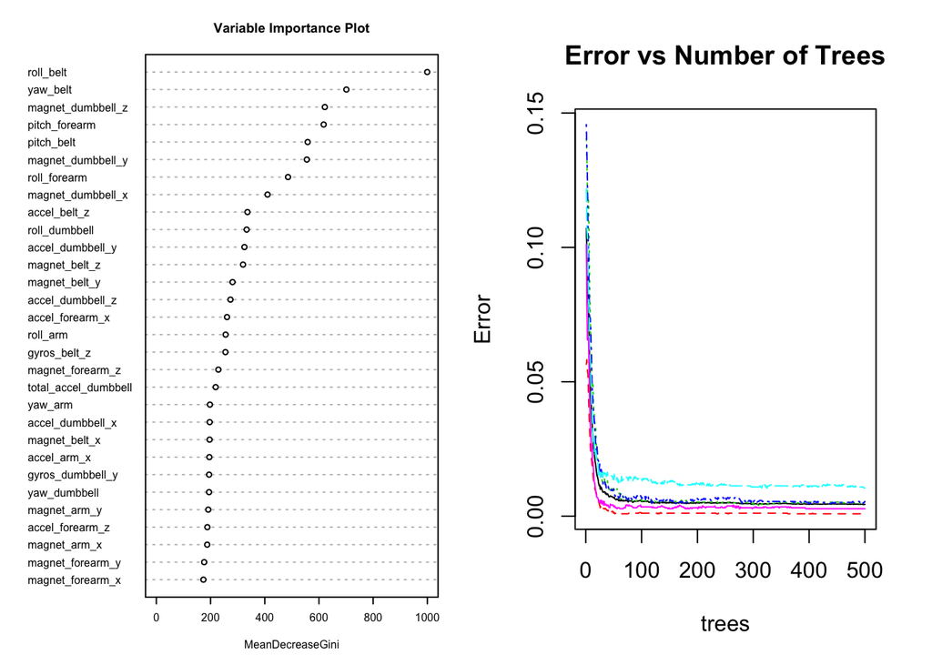

```r
par(mfrow=c(1,2))
varImpPlot(fitRF500,main='Variable Importance Plot', type=2, cex=0.5)
plot(fitRF500, main='Error vs Number of Trees')
```

### Prediction

```r
predtest <- predict (fitRF500, testing)
predtest
```

```
##  1  2  3  4  5  6  7  8  9 10 11 12 13 14 15 16 17 18 19 20
##  B  A  B  A  A  E  D  B  A  A  B  C  B  A  E  E  A  B  B  B
## Levels: A B C D E
```